# STAT-225 Group 8 Final Project Presentation

5/3/2020

## Introduction

- Dataset: `diamonds`
- Random sample: (500 observations from 54,000)
- The observational unit: a diamond
- Response variable: price in US dollars
- Explanatory variables: `carat + cut + color + clarity + depth + table + x + y + z + depth_percent`
- Note: `x` = length; `y` = width; `z` = depth; `carat` = mass; `table` = width of top of diamond

## EDA: `ggpairs`

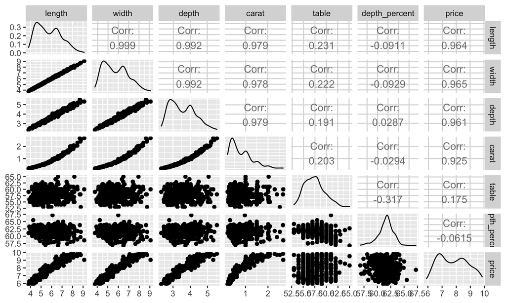

## Response variable: `price`

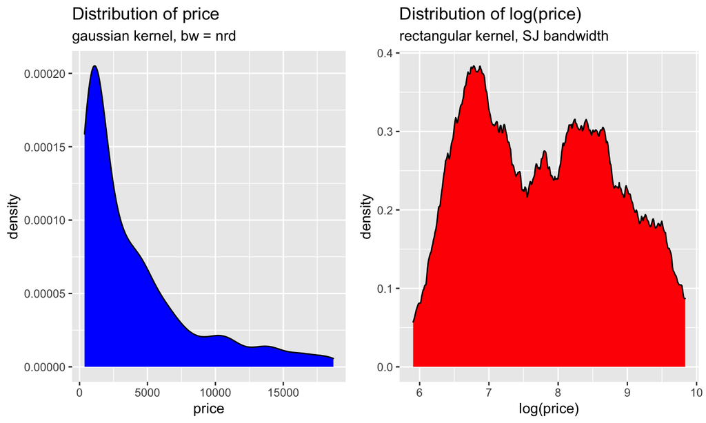

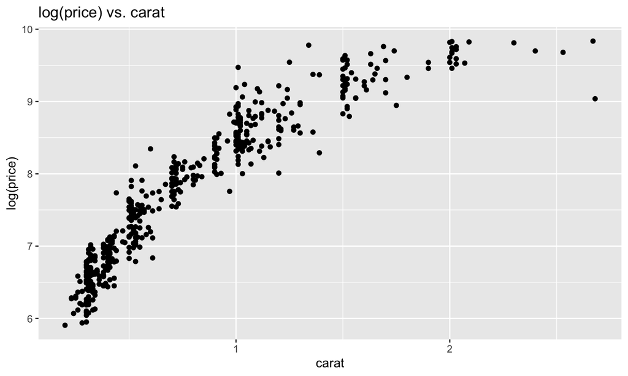

## OLS model: forward stepwise regression

| Table 1: Stepwise regression results Step | Table 1: Stepwise regression results Predictors | Table 1: Stepwise regression results \(R^2_\text{adj.}\) | Table 1: Stepwise regression results AIC |
| --- | --- | --- | --- |
| 1 | width | 0.931 | 116.286 |
| 2 | clarity | 0.956 | -100.052 |
| 3 | color | 0.969 | -265.746 |
| 4 | carat | 0.974 | -360.658 |
| 5 | depth | 0.982 | -545.237 |
| 6 | cut | 0.983 | -563.024 |
| 7 | length | 0.983 | -567.463 |

- Note that forward stepwise regression excluded `depth_percent` and `table`.

## OLS model: final model summary

| Table 2: OLS model summary results log(price) ~ width + clarity + color + carat + depth + length Predictors | Table 2: OLS model summary results log(price) ~ width + clarity + color + carat + depth + length Estimate | Table 2: OLS model summary results log(price) ~ width + clarity + color + carat + depth + length P-value | Table 2: OLS model summary results log(price) ~ width + clarity + color + carat + depth + length Predictors | Table 2: OLS model summary results log(price) ~ width + clarity + color + carat + depth + length Estimate | Table 2: OLS model summary results log(price) ~ width + clarity + color + carat + depth + length P-value |
| --- | --- | --- | --- | --- | --- |
| (Intercept) | -0.0651831 | 0.59156 | colorE | -0.0227264 | 0.30612 |
| width | 0.2949006 | 0.01319 | colorF | -0.0803849 | 0.00034 |
| clarityIF | 1.0487289 | < 0.0001 | colorG | -0.1564346 | < 0.0001 |
| claritySI1 | 0.5720697 | < 0.0001 | colorH | -0.2358815 | < 0.0001 |
| claritySI2 | 0.3951465 | < 0.0001 | colorI | -0.3170297 | < 0.0001 |
| clarityVS1 | 0.7991108 | < 0.0001 | colorJ | -0.4649712 | < 0.0001 |
| clarityVS2 | 0.7011019 | < 0.0001 | carat | -1.1056764 | < 0.0001 |
| clarityVVS1 | 0.9785003 | < 0.0001 | depth | 1.0667157 | < 0.0001 |
| clarityVVS2 | 0.9082077 | < 0.0001 | length | 0.4792458 | < 0.0001 |

\(R^2_\text{adj} = 0.983\)

## OLS or JHM? Visually examine OLS residuals for normality

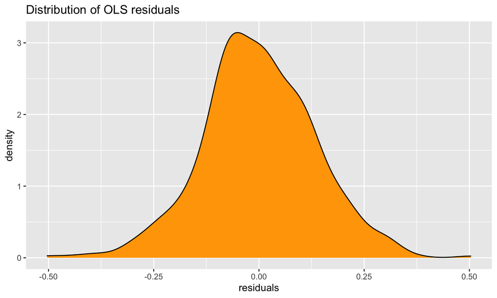

## OLS or JHM? Test OLS residuals for normality (KS)

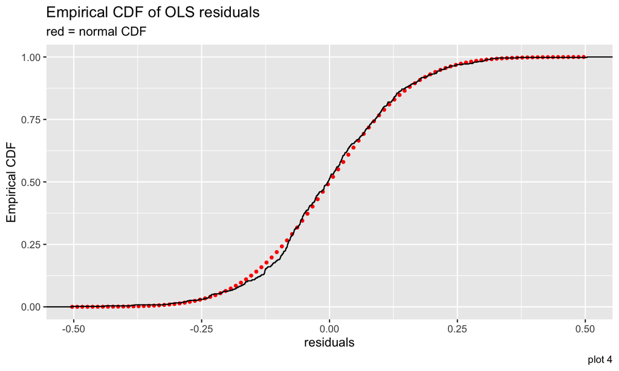

## Building a JHM model

| Table 3: JHM model summary results log(price) ~ width + clarity + color + carat + depth + length Predictors | Table 3: JHM model summary results log(price) ~ width + clarity + color + carat + depth + length Estimate | Table 3: JHM model summary results log(price) ~ width + clarity + color + carat + depth + length P-value | Table 3: JHM model summary results log(price) ~ width + clarity + color + carat + depth + length Predictors | Table 3: JHM model summary results log(price) ~ width + clarity + color + carat + depth + length Estimate | Table 3: JHM model summary results log(price) ~ width + clarity + color + carat + depth + length P-value |
| --- | --- | --- | --- | --- | --- |
| (Intercept) | 0.0090945 | 0.93893 | colorE | -0.0227499 | 0.29299 |
| width | 0.2735470 | 0.01848 | colorF | -0.0757285 | 0.00054 |
| clarityIF | 1.0108864 | < 0.0001 | colorG | -0.1425860 | < 0.0001 |
| claritySI1 | 0.5289852 | < 0.0001 | colorH | -0.2383103 | < 0.0001 |
| claritySI2 | 0.3557141 | < 0.0001 | colorI | -0.3201962 | < 0.0001 |
| clarityVS1 | 0.7575702 | < 0.0001 | colorJ | -0.4729935 | < 0.0001 |
| clarityVS2 | 0.6611988 | < 0.0001 | carat | -1.0753752 | < 0.0001 |
| clarityVVS1 | 0.9197320 | < 0.0001 | depth | 1.0497605 | < 0.0001 |
| clarityVVS2 | 0.8545020 | < 0.0001 | length | 0.5006167 | < 0.0001 |

## Plotting JHM model - quantitative predictors

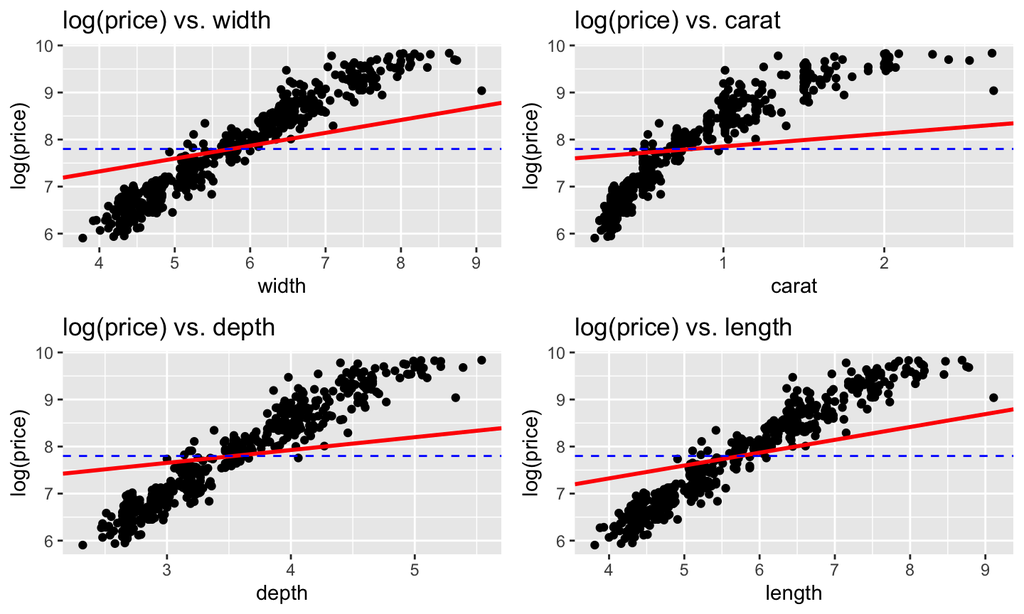

## Plotting JHM model - categorical predictors

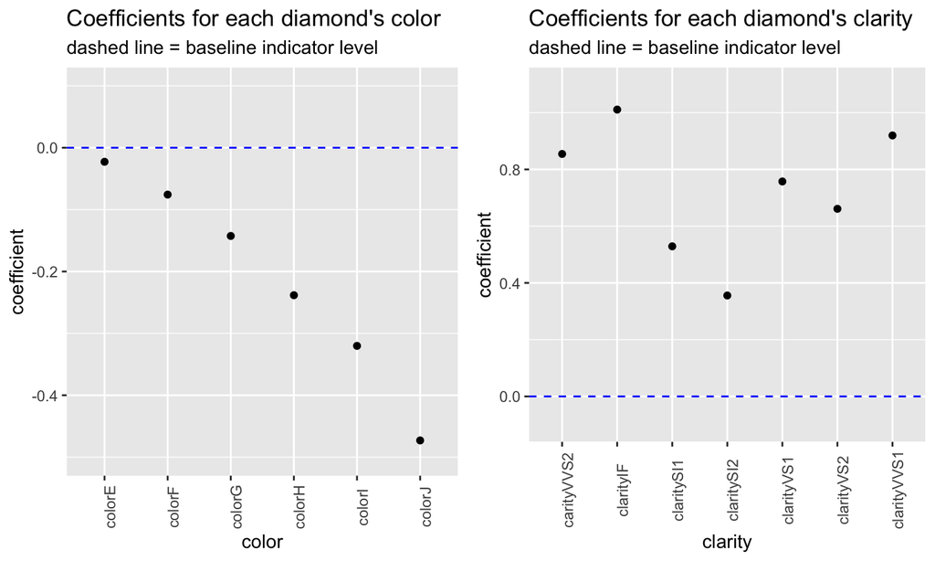

## GAM: smoother or SLR for quantitative predictors?

| Table 4: SLR vs. smooth \(R^2_\text{adj}\) Predictor | Table 4: SLR vs. smooth \(R^2_\text{adj}\) SLR | Table 4: SLR vs. smooth \(R^2_\text{adj}\) Smooth |
| --- | --- | --- |
| width | 0.931 | 0.943 |
| length | 0.929 | 0.942 |
| carat | 0.856 | 0.941 |
| depth | 0.87 | 0.935 |

- Note: \(R^2_\text{adj}\) for smoothing spline was higher for all quantitative predictors.

## GAM: choosing the best model

| Table 5: Comparison of AIC between GAM models Model | Table 5: Comparison of AIC between GAM models AIC |
| --- | --- |
| color + clarity + s(length) + s(width) + s(depth) + s(carat) | -649.94 |
| color + clarity + length + width + s(depth) + s(carat) | -612.54 |
| color + clarity + depth + carat + s(width) | -596.29 |
| color + clarity + depth + carat + width + length | -545.24 |
| color + clarity + depth + carat + s(width) + s(length) | -652.97 |

- The model with predictors `clarity + color + depth + carat + s(width) + s(length)` had the lowest AIC (-652).

## GAM: plotting chosen model

- Note: red = smoother; gold = GAM

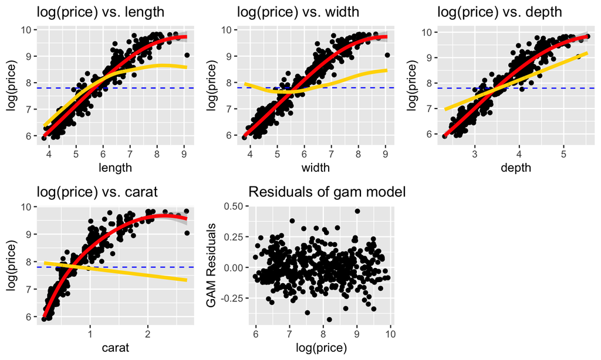

## GAM: explaining the roles of `carat` and `width` in the model

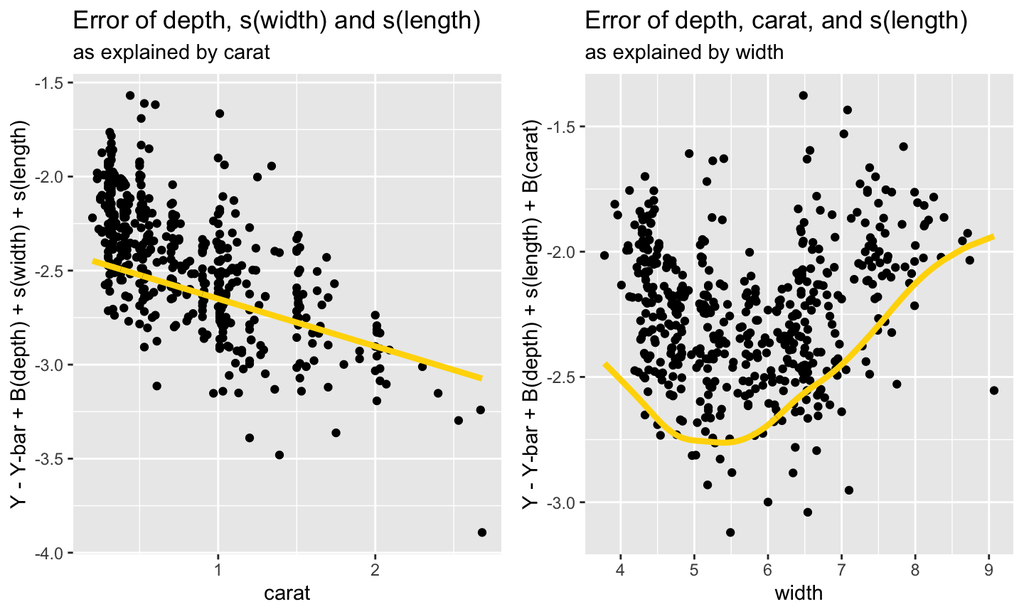

## Examining residuals: all attempted models

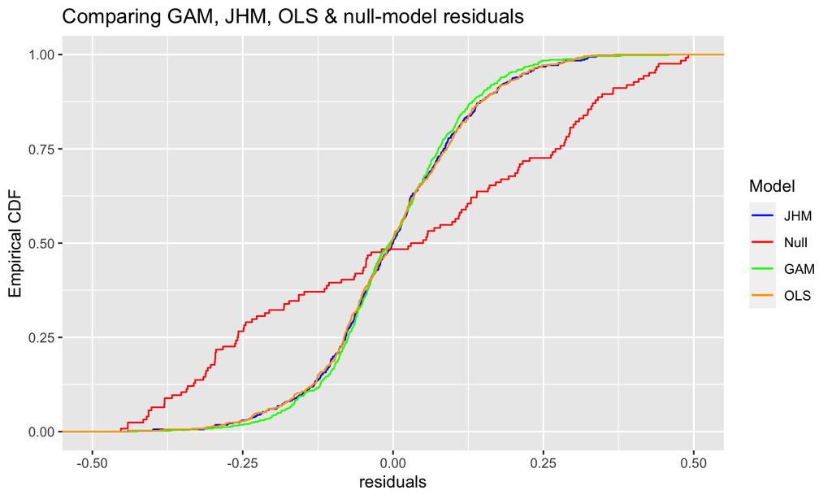

## Assessing model fit: cross-validation

| Table 6: Results from cross-validation Regular approach | Table 6: Results from cross-validation Regular approach \(R^2\) | Table 6: Results from cross-validation Regular approach \(R^2_\text{adj}\) | Table 6: Results from cross-validation Regular approach \(L1_{\text{prop}}\) | Table 6: Results from cross-validation Cross-validation approach \(R^2\) | Table 6: Results from cross-validation Cross-validation approach \(R^2_\text{adj}\) | Table 6: Results from cross-validation Cross-validation approach \(L1_{\text{prop}}\) |
| --- | --- | --- | --- | --- | --- | --- |
| OLS | 0.9833 | 0.9827 | 0.8842 | 0.9816 | 0.9809 | 0.8789 |
| JHM | 0.9832 | 0.9826 | 0.8852 | 0.9817 | 0.981 | 0.8796 |
| GAM | 0.9828 | 0.9822 | 0.8817 | 0.9847 | 0.9838 | 0.8892 |

- GAM outperforms the other models (look at cross-validation)
- \(R^2\) values: OLS fails to explain 1.84% of the variability, while GAM fails to explain 1.53% of the variability
- Using the GAM model results in a 16% decrease in unexplained variability (relative to OLS).

## Limitations

- Multicollinearity between `carat`, `length`, `width`, and `depth`.
- We don’t know what year this dataset is from
  - If we did, we could use our model to predict diamond price and adjust for inflation.

## Conclusions

- **Recall:** How can we predict diamond price?
- **Best model:** utilizes a GAM
  - Predictors: `clarity + color + depth + carat + s(width) + s(length)`